# ELAVL1 KO analysis in irradiated MCF7 and MB231 cell lines

The data were normalized by *Endogenous control*, then using quantile normalization. The Ct values were converted to expression counts using 2<sup>-Ct</sup> formula.

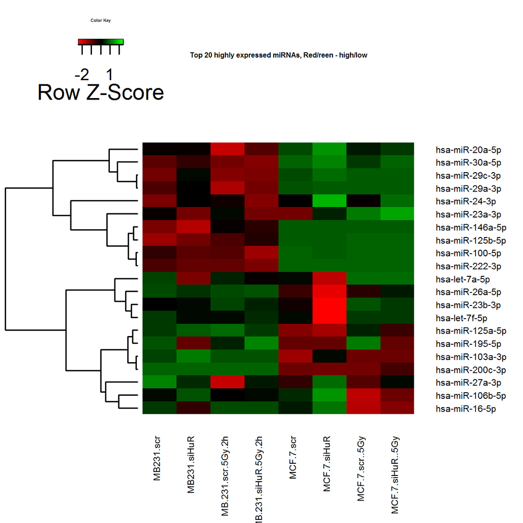

Principal component analysis for each cell type shows we have both siRNA and Rad effects.

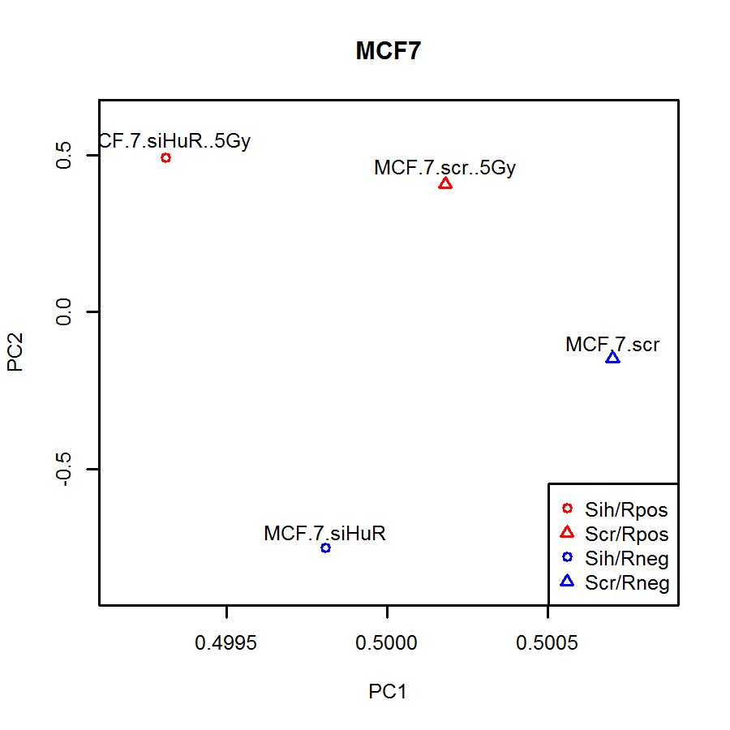

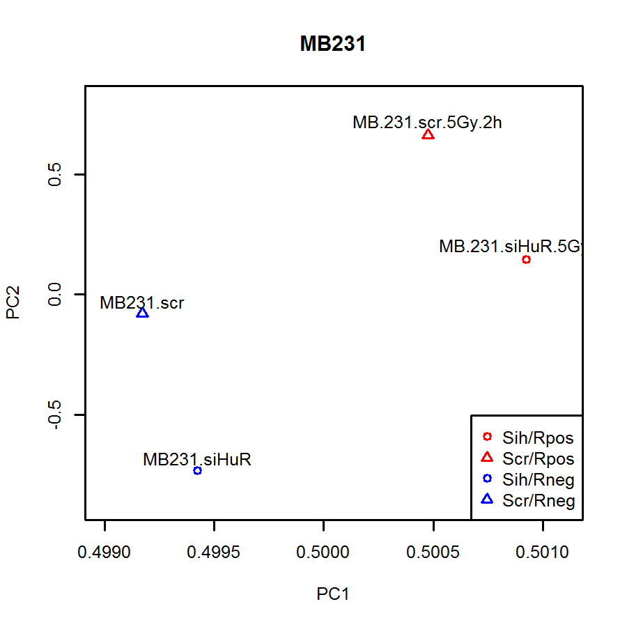

For each miRNA we define a ratio of siRNA effect in non-irradiated vs. irradiated cells, referred hereafter as the ratio.

## MCF7

First, we look at the distribution of the ratio. Then, we fit a normal distribution to it, and define min/max cutoffs as 1 standard deviation around its mean. We check how many miRNAs are above the maximum or below the minimum thresholds and visualize their normalized expression counts as a heatmap. We also check the raw Ct values for these miRNAs.

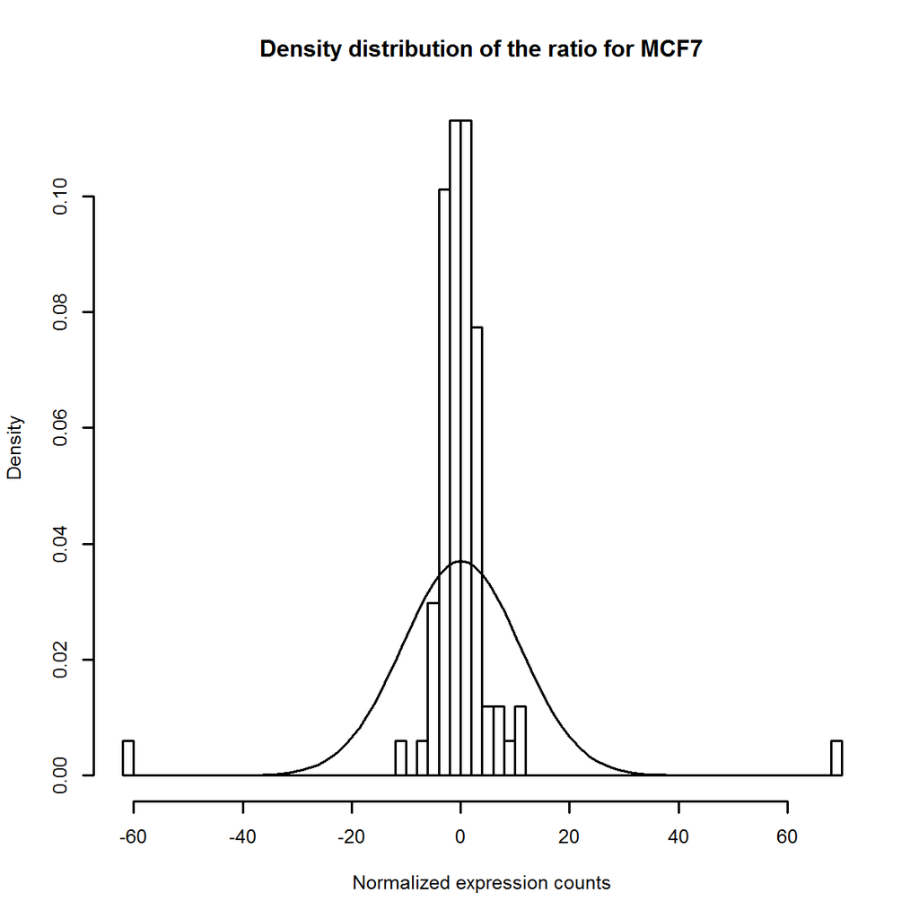

```
## Min threshold: -10.65 how many miRNAs: 2 Max threshold: 10.86 how many miRNAs: 2
```

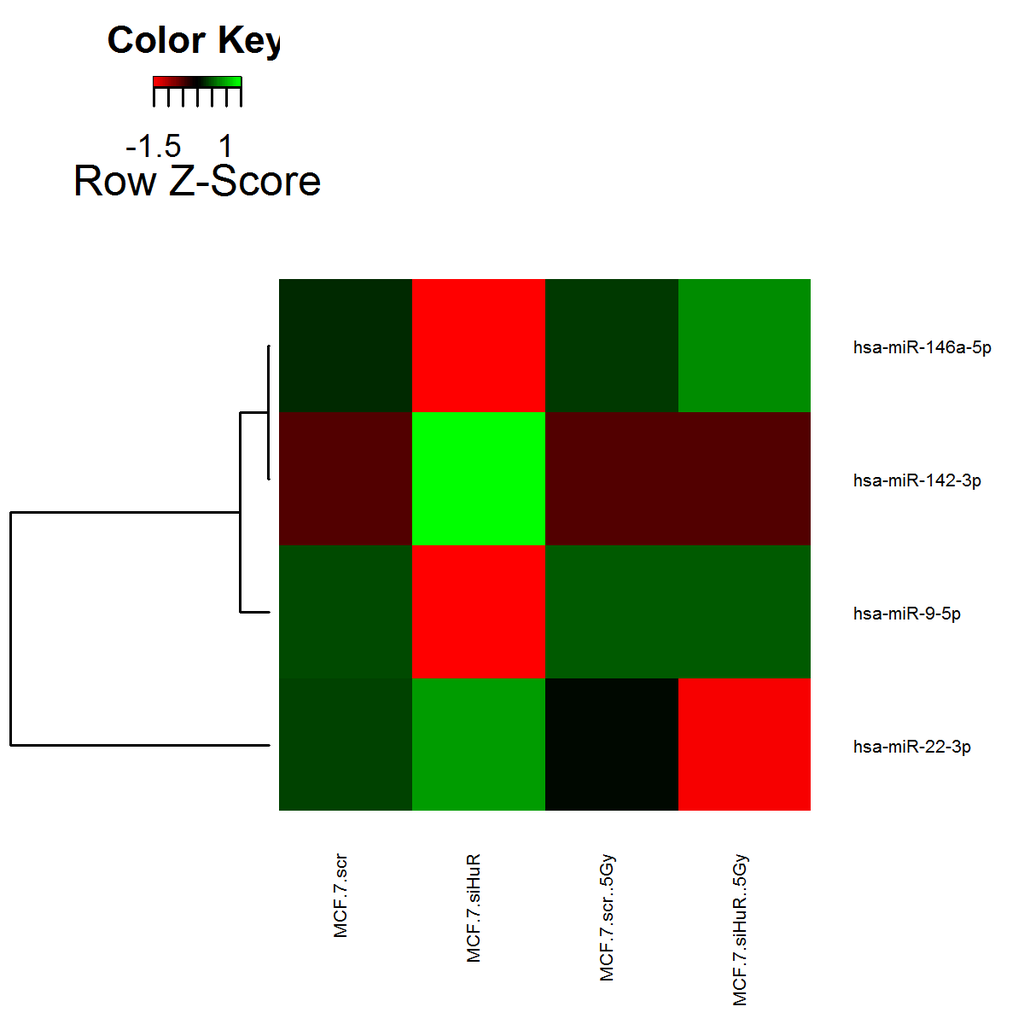

```
## Raw Ct values
##                        MCF.7.scr MCF.7.siHuR MCF.7.scr..5Gy MCF.7.siHuR..5Gy
## [1,] "hsa-miR-9-5p"    "26.75"   "28.01"     "27.04"        "26.2"
## [2,] "hsa-miR-142-3p"  "31.55"   "39.74"     "31.09"        "29.88"
## [3,] "hsa-miR-146a-5p" "33.03"   "35.01"     "33.51"        "35.96"
## [4,] "hsa-miR-22-3p"   "22.11"   "29"        "21.49"        "19.79"
##
## Normalized Ct values
##
##       Note that the mean of endogenous control probes was subtracted from the Ct values, hence some values are negative. Look for RELATIVE comparisons, not absolute Ct values.
##                 MCF.7.scr MCF.7.siHuR MCF.7.scr..5Gy MCF.7.siHuR..5Gy
## hsa-miR-9-5p    "0.1242"  "1.3424"    "0.0675"       "0.0675"
## hsa-miR-142-3p  "0.0061"  "0.0001"    "0.0061"       "0.0061"
## hsa-miR-146a-5p "0.0015"  "0.0061"    "0.0013"       "0.0001"
## hsa-miR-22-3p   "3.0310"  "0.6500"    "4.5113"       "11.0027"
```

We observe two outliers on both sides of the distribution. They expand the fitting of the normal distribution, and make min/max thresholds overinflated.

To alleviate this bias, we remove those outliers, check the cutoffs and the number of miRNAs above the cutoffs, visualize them as a heatmap and look at their raw Ct values.

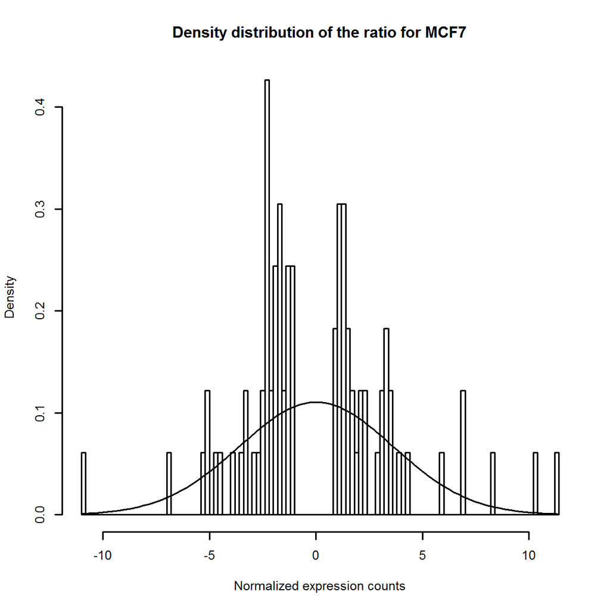

```
## Min threshold: -3.596 how many miRNAs: 8 Max threshold: 3.621 how many miRNAs: 8
```

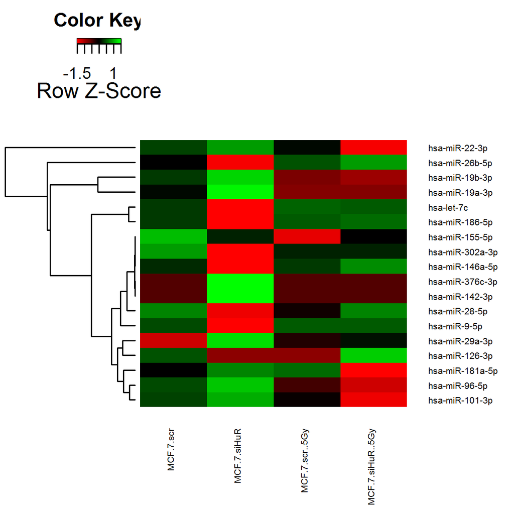

```
## Raw Ct values
##                         MCF.7.scr MCF.7.siHuR MCF.7.scr..5Gy MCF.7.siHuR..5Gy
##  [1,] "hsa-miR-9-5p"    "26.75"   "28.01"     "27.04"        "26.2"
##  [2,] "hsa-miR-101-3p"  "24.43"   "30.49"     "23.91"        "22.46"
##  [3,] "hsa-miR-26b-5p"  "21.89"   "23.83"     "22.47"        "23.08"
##  [4,] "hsa-miR-96-5p"   "24.7"    "32.06"     "23.93"        "22.86"
##  [5,] "hsa-miR-142-3p"  "31.55"   "39.74"     "31.09"        "29.88"
##  [6,] "hsa-miR-155-5p"  "34.33"   "36.88"     "33.18"        "33.6"
##  [7,] "hsa-miR-146a-5p" "33.03"   "35.01"     "33.51"        "35.96"
##  [8,] "hsa-miR-181a-5p" "23.62"   "29.2"      "24.06"        "22.28"
##  [9,] "hsa-miR-28-5p"   "25.75"   "29.16"     "24.96"        "24.8"
## [10,] "hsa-miR-29a-3p"  "23.17"   "30.12"     "23.69"        "23.36"
## [11,] "hsa-miR-19a-3p"  "21.92"   "29.29"     "21.34"        "20.95"
## [12,] "hsa-miR-376c-3p" "31.59"   "39.5"      "31.15"        "30.16"
## [13,] "hsa-miR-126-3p"  "24.31"   "28.23"     "23.42"        "23.46"
## [14,] "hsa-miR-302a-3p" "34.1"    "36.36"     "33.74"        "33.55"
## [15,] "hsa-miR-19b-3p"  "23.09"   "29.5"      "22.22"        "21.5"
## [16,] "hsa-miR-186-5p"  "24.04"   "25.54"     "24.33"        "24.07"
## [17,] "hsa-miR-22-3p"   "22.11"   "29"        "21.49"        "19.79"
## [18,] "hsa-let-7c"      "24.37"   "25.7"      "25.3"         "24.51"
##
## Normalized Ct values
##
##       Note that the mean of endogenous control probes was subtracted from the Ct values, hence some values are negative. Look for RELATIVE comparisons, not absolute Ct values.
##                 MCF.7.scr MCF.7.siHuR MCF.7.scr..5Gy MCF.7.siHuR..5Gy
## hsa-miR-9-5p    "0.1242"  "1.3424"    "0.0675"       "0.0675"
## hsa-miR-101-3p  "0.4928"  "0.1413"    "0.8016"       "1.5936"
## hsa-miR-26b-5p  "3.4367"  "6.9574"    "2.1137"       "0.9641"
## hsa-miR-96-5p   "0.3779"  "0.0675"    "0.7383"       "1.0828"
## hsa-miR-142-3p  "0.0061"  "0.0001"    "0.0061"       "0.0061"
## hsa-miR-155-5p  "0.0002"  "0.0007"    "0.0015"       "0.0008"
## hsa-miR-146a-5p "0.0015"  "0.0061"    "0.0013"       "0.0001"
## hsa-miR-181a-5p "0.9641"  "0.5082"    "0.5992"       "1.8465"
## hsa-miR-28-5p   "0.2109"  "0.5992"    "0.3779"       "0.2109"
## hsa-miR-29a-3p  "1.2755"  "0.2783"    "0.8887"       "0.7383"
## hsa-miR-19a-3p  "3.3312"  "0.4779"    "5.1552"       "5.1552"
## hsa-miR-376c-3p "0.0048"  "0.0005"    "0.0048"       "0.0048"
## hsa-miR-126-3p  "0.7383"  "1.2161"    "1.2161"       "0.5082"
## hsa-miR-302a-3p "0.0005"  "0.0022"    "0.0010"       "0.0010"
## hsa-miR-19b-3p  "1.4959"  "0.3779"    "2.9227"       "3.1817"
## hsa-miR-186-5p  "0.8496"  "3.9718"    "0.5499"       "0.3779"
## hsa-miR-22-3p   "3.0310"  "0.6500"    "4.5113"       "11.0027"
## hsa-let-7c      "0.5992"  "3.5014"    "0.2783"       "0.3169"
```

## MB231

We repeat the same steps for MB231 cell line, first using the data as is,

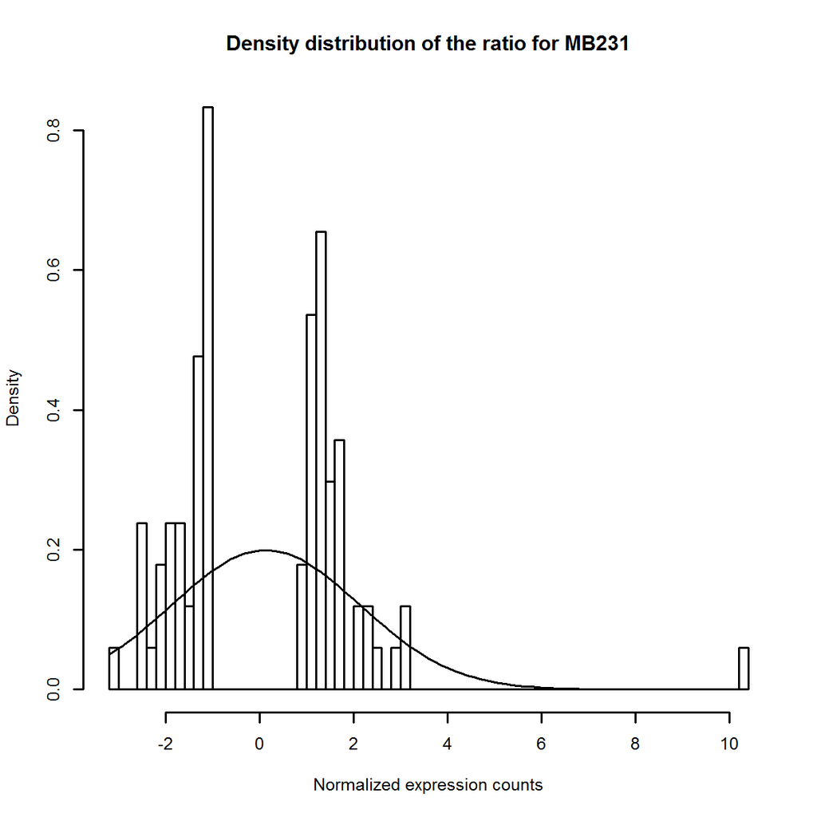

```
## Min threshold: -1.869 how many miRNAs: 11 Max threshold: 2.133 how many miRNAs: 7
```

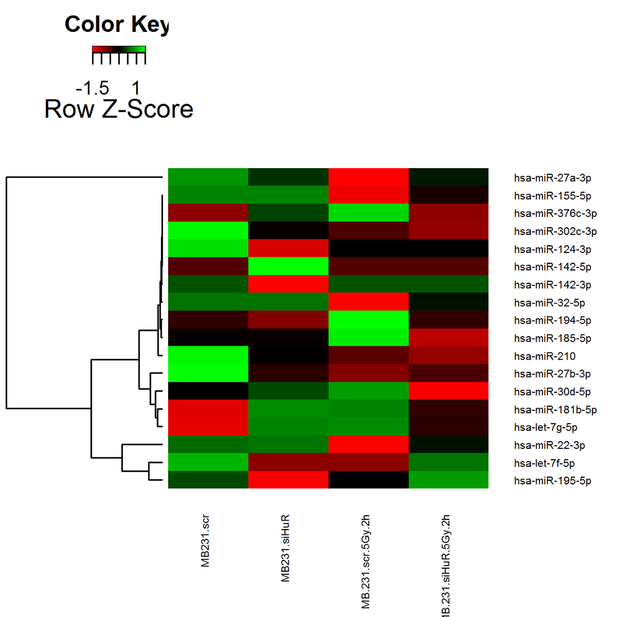

```
## Raw Ct values
##                         MB231.scr MB231.siHuR MB.231.scr.5Gy.2h MB.231.siHuR.5Gy.2h
##  [1,] "hsa-miR-142-5p"  "31.62"   "33.5"      "30.13"           "30.31"
##  [2,] "hsa-miR-27b-3p"  "23.24"   "22.81"     "21.4"            "21.26"
##  [3,] "hsa-miR-32-5p"   "30.26"   "30.94"     "25.49"           "26.54"
##  [4,] "hsa-let-7g-5p"   "21.98"   "23.16"     "22.01"           "21.33"
##  [5,] "hsa-miR-185-5p"  "26.5"    "26.72"     "26.08"           "25.25"
##  [6,] "hsa-miR-142-3p"  "29.12"   "28.68"     "27.73"           "27.09"
##  [7,] "hsa-miR-155-5p"  "39.74"   "39.74"     "36.02"           "35.85"
##  [8,] "hsa-miR-181b-5p" "22.37"   "23.45"     "22.22"           "21.59"
##  [9,] "hsa-miR-194-5p"  "26.9"    "27.1"      "26.16"           "26.01"
## [10,] "hsa-miR-210"     "26.56"   "25.4"      "24.01"           "23.94"
## [11,] "hsa-miR-124-3p"  "32.32"   "32.16"     "30.83"           "30.58"
## [12,] "hsa-miR-376c-3p" "34.45"   "35.67"     "36.12"           "33.79"
## [13,] "hsa-miR-195-5p"  "21.27"   "21.04"     "20.17"           "20.24"
## [14,] "hsa-miR-30d-5p"  "22.84"   "23.14"     "22.18"           "21.06"
## [15,] "hsa-miR-27a-3p"  "20.24"   "20.3"      "18.62"           "19.04"
## [16,] "hsa-miR-22-3p"   "22.21"   "22.8"      "19.75"           "20.49"
## [17,] "hsa-let-7f-5p"   "21.56"   "21.25"     "20.15"           "20.45"
## [18,] "hsa-miR-302c-3p" "36.17"   "35.19"     "33.09"           "32.28"
##
## Normalized Ct values
##
##       Note that the mean of endogenous control probes was subtracted from the Ct values, hence some values are negative. Look for RELATIVE comparisons, not absolute Ct values.
##                 MB231.scr MB231.siHuR MB.231.scr.5Gy.2h MB.231.siHuR.5Gy.2h
## hsa-miR-142-5p  "0.0048"  "0.0022"    "0.0048"          "0.0048"
## hsa-miR-27b-3p  "1.2161"  "2.2753"    "2.5709"          "2.3719"
## hsa-miR-32-5p   "0.0115"  "0.0115"    "0.1242"          "0.0399"
## hsa-let-7g-5p   "2.9227"  "1.4443"    "1.3945"          "2.1930"
## hsa-miR-185-5p  "0.1540"  "0.1540"    "0.0675"          "0.2109"
## hsa-miR-142-3p  "0.0269"  "0.0675"    "0.0269"          "0.0269"
## hsa-miR-155-5p  "0.0000"  "0.0000"    "0.0002"          "0.0001"
## hsa-miR-181b-5p "2.2753"  "1.1706"    "1.2161"          "1.7790"
## hsa-miR-194-5p  "0.1072"  "0.1242"    "0.0399"          "0.1072"
## hsa-miR-210     "0.1242"  "0.3426"    "0.4229"          "0.4779"
## hsa-miR-124-3p  "0.0022"  "0.0048"    "0.0035"          "0.0035"
## hsa-miR-376c-3p "0.0005"  "0.0002"    "0.0001"          "0.0005"
## hsa-miR-195-5p  "5.8962"  "8.7002"    "6.5764"          "5.1552"
## hsa-miR-30d-5p  "1.8465"  "1.5936"    "1.2755"          "2.7626"
## hsa-miR-27a-3p  "9.5702"  "12.3948"   "21.4595"         "13.0845"
## hsa-miR-22-3p   "2.4748"  "2.3719"    "8.7002"          "3.9718"
## hsa-let-7f-5p   "4.1512"  "6.9574"    "6.9574"          "4.7233"
## hsa-miR-302c-3p "0.0002"  "0.0007"    "0.0008"          "0.0010"
```

then, trimming outliers.

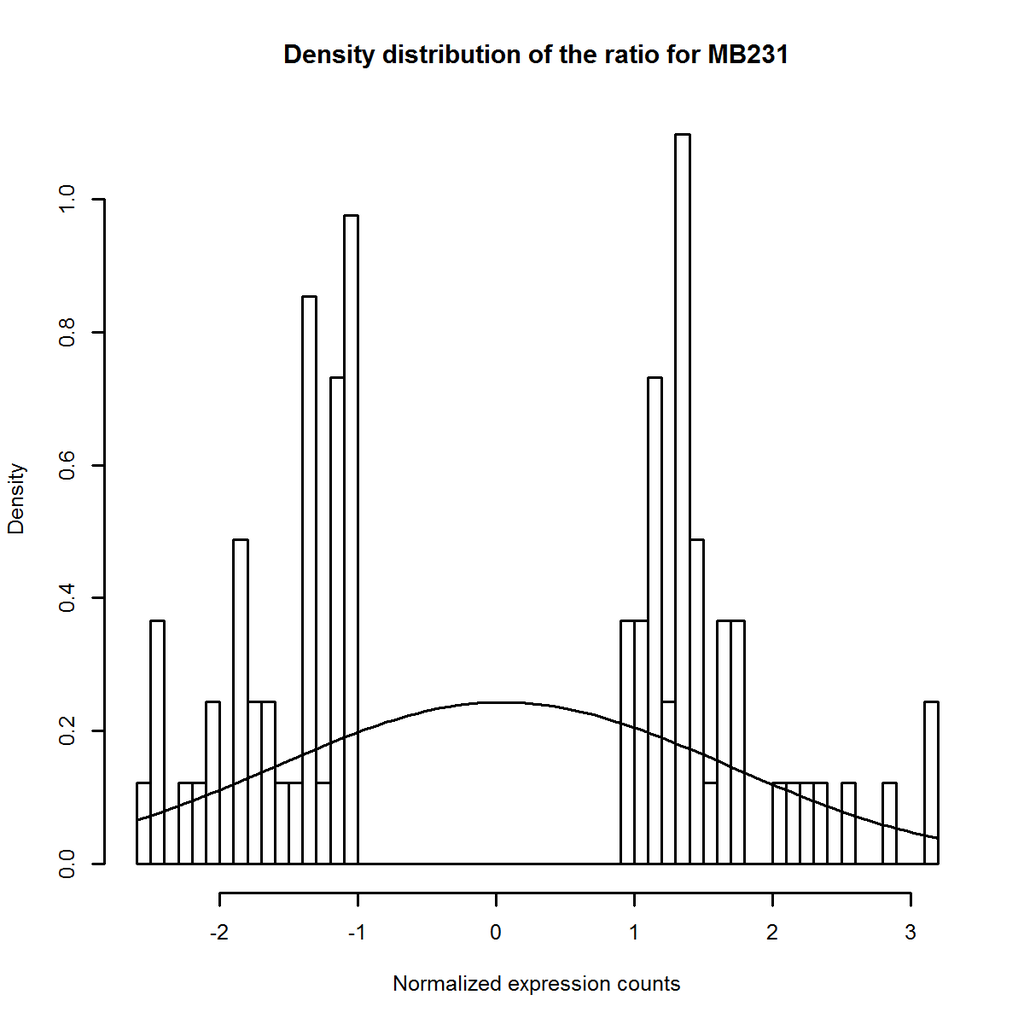

```
## Min threshold: -1.592 how many miRNAs: 16 Max threshold: 1.688 how many miRNAs: 11
```

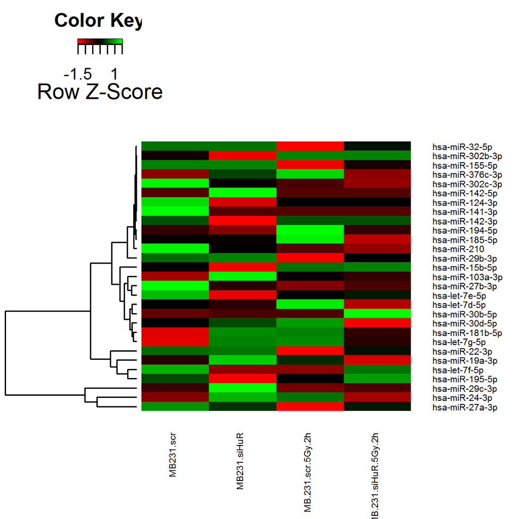

```
## Raw Ct values
##                         MB231.scr MB231.siHuR MB.231.scr.5Gy.2h MB.231.siHuR.5Gy.2h
##  [1,] "hsa-miR-142-5p"  "31.62"   "33.5"      "30.13"           "30.31"
##  [2,] "hsa-miR-27b-3p"  "23.24"   "22.81"     "21.4"            "21.26"
##  [3,] "hsa-let-7d-5p"   "23.11"   "23.16"     "22.51"           "21.71"
##  [4,] "hsa-miR-103a-3p" "21.79"   "23.02"     "21.17"           "20.65"
##  [5,] "hsa-miR-32-5p"   "30.26"   "30.94"     "25.49"           "26.54"
##  [6,] "hsa-let-7g-5p"   "21.98"   "23.16"     "22.01"           "21.33"
##  [7,] "hsa-miR-185-5p"  "26.5"    "26.72"     "26.08"           "25.25"
##  [8,] "hsa-miR-142-3p"  "29.12"   "28.68"     "27.73"           "27.09"
##  [9,] "hsa-miR-24-3p"   "19.7"    "20.82"     "19.32"           "18.93"
## [10,] "hsa-miR-155-5p"  "39.74"   "39.74"     "36.02"           "35.85"
## [11,] "hsa-miR-181b-5p" "22.37"   "23.45"     "22.22"           "21.59"
## [12,] "hsa-miR-302b-3p" "37.86"   "38.35"     "39.74"           "39.74"
## [13,] "hsa-miR-30b-5p"  "22.86"   "23.12"     "21.87"           "22.38"
## [14,] "hsa-miR-15b-5p"  "21.82"   "21.65"     "21.44"           "21.33"
## [15,] "hsa-miR-194-5p"  "26.9"    "27.1"      "26.16"           "26.01"
## [16,] "hsa-miR-210"     "26.56"   "25.4"      "24.01"           "23.94"
## [17,] "hsa-miR-29b-3p"  "24.34"   "25.11"     "21.59"           "22.24"
## [18,] "hsa-miR-141-3p"  "31.71"   "31.71"     "29.35"           "29.64"
## [19,] "hsa-miR-19a-3p"  "21.44"   "22.1"      "20.5"            "19.89"
## [20,] "hsa-miR-124-3p"  "32.32"   "32.16"     "30.83"           "30.58"
## [21,] "hsa-let-7e-5p"   "22.53"   "22.33"     "21.33"           "21.15"
## [22,] "hsa-miR-376c-3p" "34.45"   "35.67"     "36.12"           "33.79"
## [23,] "hsa-miR-195-5p"  "21.27"   "21.04"     "20.17"           "20.24"
## [24,] "hsa-miR-30d-5p"  "22.84"   "23.14"     "22.18"           "21.06"
## [25,] "hsa-miR-27a-3p"  "20.24"   "20.3"      "18.62"           "19.04"
## [26,] "hsa-miR-22-3p"   "22.21"   "22.8"      "19.75"           "20.49"
## [27,] "hsa-miR-29c-3p"  "19.42"   "20.89"     "18.61"           "18.55"
## [28,] "hsa-let-7f-5p"   "21.56"   "21.25"     "20.15"           "20.45"
## [29,] "hsa-miR-302c-3p" "36.17"   "35.19"     "33.09"           "32.28"
##
## Normalized Ct values
##
##       Note that the mean of endogenous control probes was subtracted from the Ct values, hence some values are negative. Look for RELATIVE comparisons, not absolute Ct values.
##                 MB231.scr MB231.siHuR MB.231.scr.5Gy.2h MB.231.siHuR.5Gy.2h
## hsa-miR-142-5p  "0.0048"  "0.0022"    "0.0048"          "0.0048"
## hsa-miR-27b-3p  "1.2161"  "2.2753"    "2.5709"          "2.3719"
## hsa-let-7d-5p   "1.3424"  "1.4443"    "0.8887"          "1.7169"
## hsa-miR-103a-3p "3.5672"  "2.1137"    "3.0310"          "3.1817"
```

[output cut: 10 more lines]

```
## hsa-miR-194-5p  "0.1072"  "0.1242"    "0.0399"          "0.1072"
## hsa-miR-210     "0.1242"  "0.3426"    "0.4229"          "0.4779"
## hsa-miR-29b-3p  "0.5499"  "0.4229"    "2.2753"          "1.0828"
## hsa-miR-141-3p  "0.0035"  "0.0061"    "0.0061"          "0.0061"
## hsa-miR-19a-3p  "5.3882"  "3.5672"    "4.7233"          "6.5764"
## hsa-miR-124-3p  "0.0022"  "0.0048"    "0.0035"          "0.0035"
## hsa-let-7e-5p   "2.1137"  "3.3312"    "2.6593"          "2.5709"
## hsa-miR-376c-3p "0.0005"  "0.0002"    "0.0001"          "0.0005"
## hsa-miR-195-5p  "5.8962"  "8.7002"    "6.5764"          "5.1552"
## hsa-miR-30d-5p  "1.8465"  "1.5936"    "1.2755"          "2.7626"
## hsa-miR-27a-3p  "9.5702"  "12.3948"   "21.4595"         "13.0845"
## hsa-miR-22-3p   "2.4748"  "2.3719"    "8.7002"          "3.9718"
## hsa-miR-29c-3p  "20.7824" "9.5702"    "22.6046"         "21.4595"
## hsa-let-7f-5p   "4.1512"  "6.9574"    "6.9574"          "4.7233"
## hsa-miR-302c-3p "0.0002"  "0.0007"    "0.0008"          "0.0010"
```

## Overlap between cell lines

First, check overlap between the most significant miRNAs (without removing outliers).

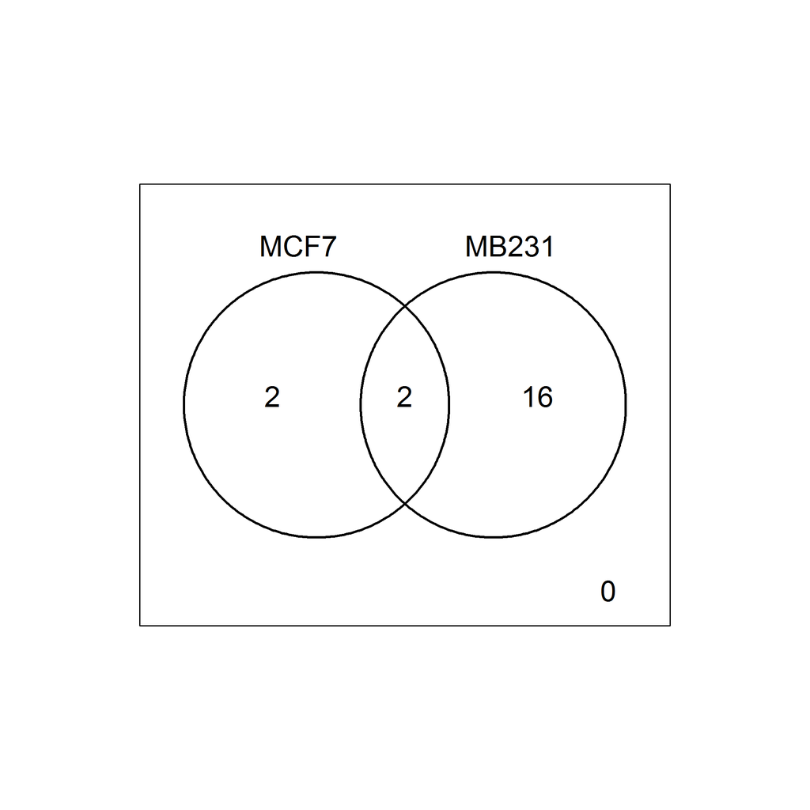

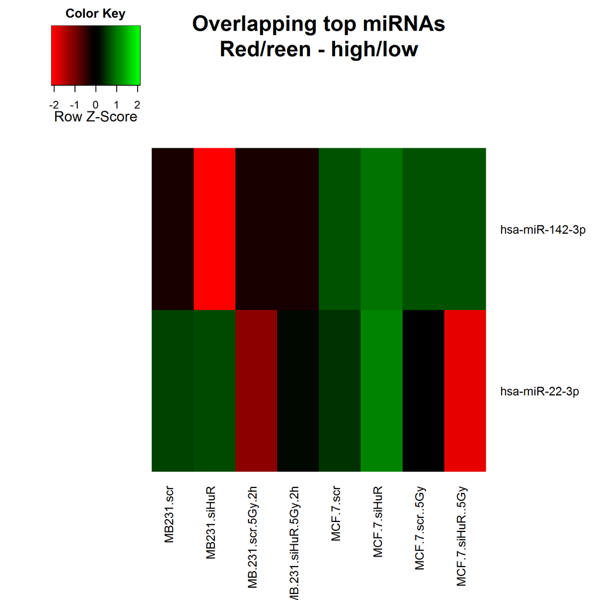

```
##
## Normalized RELATIVE Ct value changes
```

```
##                MB231.scr MB231.siHuR MB.231.scr.5Gy.2h MB.231.siHuR.5Gy.2h MCF.7.scr MCF.7.siHuR MCF.7.scr..5Gy
## hsa-miR-142-3p     5.214       3.889             5.214               5.214     7.355     13.4640          7.355
## hsa-miR-22-3p     -1.307      -1.246            -3.121              -1.990    -1.600      0.6215         -2.174
##                MCF.7.siHuR..5Gy
## hsa-miR-142-3p            7.355
## hsa-miR-22-3p            -3.460
```

Then, check overlap between the larger lists of significant miRNAs (with removing outliers).

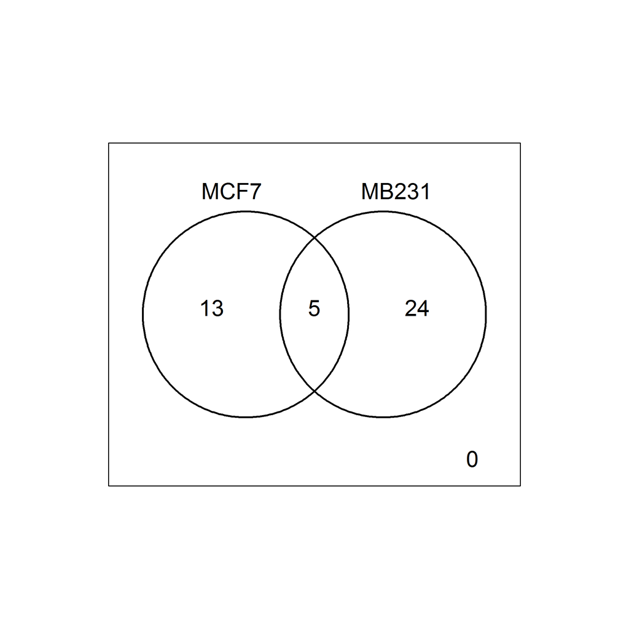

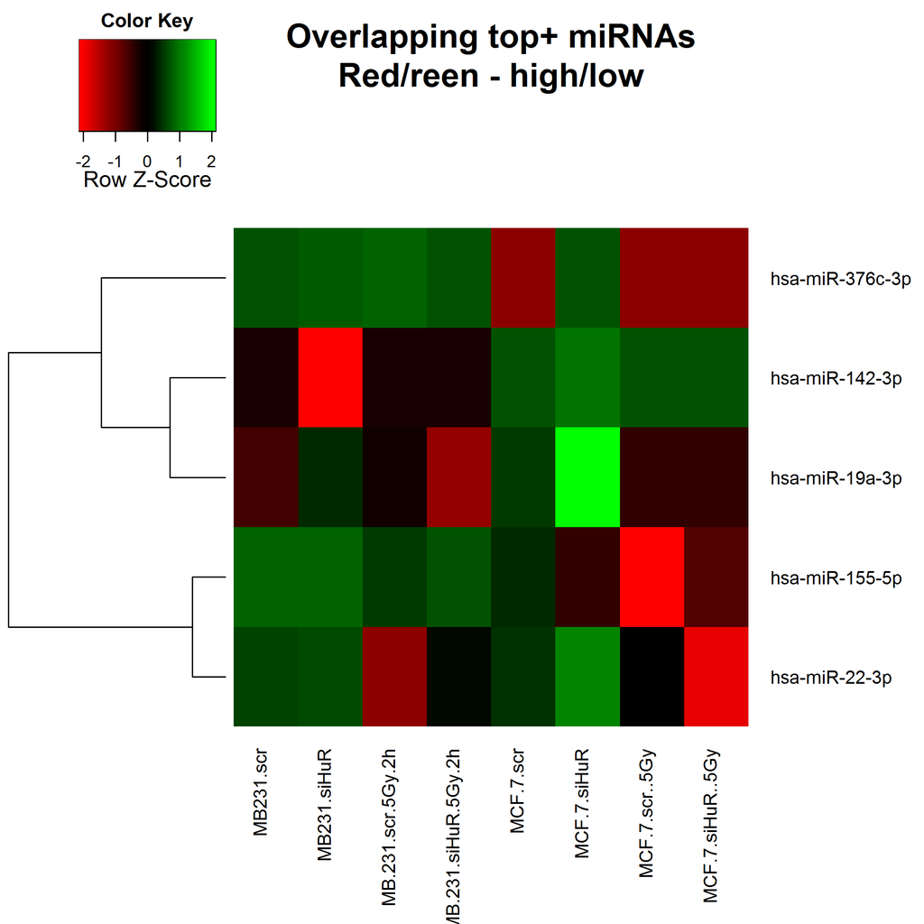

```
##
## Normalized RELATIVE Ct value changes
```

```
##                 MB231.scr MB231.siHuR MB.231.scr.5Gy.2h MB.231.siHuR.5Gy.2h MCF.7.scr MCF.7.siHuR MCF.7.scr..5Gy
## hsa-miR-142-3p      5.214       3.889             5.214               5.214     7.355     13.4640          7.355
## hsa-miR-155-5p     15.660      15.660            12.539              13.464    12.021     10.4877          9.385
## hsa-miR-19a-3p     -2.430      -1.835            -2.240              -2.717    -1.736      1.0652         -2.366
## hsa-miR-376c-3p    11.060      12.021            13.464              11.060     7.703     11.0602          7.703
## hsa-miR-22-3p      -1.307      -1.246            -3.121              -1.990    -1.600      0.6215         -2.174
##                 MCF.7.siHuR..5Gy
## hsa-miR-142-3p             7.355
## hsa-miR-155-5p            10.258
## hsa-miR-19a-3p            -2.366
## hsa-miR-376c-3p            7.703
## hsa-miR-22-3p             -3.460
```